# SDE Examples

## AR(1) SDE model (no covariates)

AR(1) SDE models are used widely in oceanography. Example applications include Cummins and Lagerloef (2002) estimating Ekman forcing on pyrocline depth variability, ecosystem response to climate forcing (Di Lorenzo 2010, Di Lorenzo & Ohman 2013). These models appear to generally ignore observation error, and fit parameters using least squares (e.g. Chhak et al. 2009). In these stochastic differential equation models, the general notation is

$$\frac { dx(t) }{ dt } =-\theta x(t)+\epsilon(t)$$
where $x(t)$ is the variable of interest (response), $\theta$ is the decay parameter, and $\epsilon(t)$ represents some white noise or forcing variable. In some papers, $\theta$ is expressed as $\tau =\frac { 1 }{ \theta }$, where $\tau$ represents the the timescale over which fluctuations are dampened.

In many of the applications of this approach in the oceanography literature, $\theta$ or $\tau$ are fixed at known values. An additional consideration is the inclusion (or not) of observation or non-process errors; few applications explicitly include this term. Another consideration is the approximation used to solve the SDE. Some have used trapezoidal approaches (e.g. Cummins and Lagerloef 2002) but most have relied on Euler schemes (Di Lorenzo and Ohman 2014). This is also described in the [Wikipedia implementation](https://en.wikipedia.org/wiki/Euler%E2%80%93Maruyama_method#Computer_implementation).

### Existing approaches

A number of packages exist for solving these models in R (there’s also a large range of other code out there, e.g. [Matlab](https://math.stackexchange.com/questions/1287634/implementing-ornstein-uhlenbeck-in-matlab) or [Python](https://discourse.pymc.io/t/estimate-ornstein-uhlenbeck-parameters-with-euler-maruyama/1356)). These include [Sim.DiffProc](https://cran.r-project.org/web/packages/Sim.DiffProc/vignettes/snssde.html#ornstein-uhlenbeck-process-and-its-integral) or [sde](https://cran.r-project.org/web/packages/sde/index.html). The sde package is particularly useful because it includes maximum likelihood estimation [see blog post here](https://renkun.me/2014/04/15/fit-an-ornstein-uhlenbeck-process-with-discrete-time-series-data/) [or here](https://www.r-bloggers.com/fit-an-ornstein-uhlenbeck-process-with-discrete-time-series-data/).

### MLE example

We’ll start with the MLE example, using the functions from sde. So that all of the examples run faster, we’ll use just time series from 2006-2012.

```r
d = read.csv("data/example slp sst data.csv",
  stringsAsFactors = FALSE)

# filter out NAs
d = dplyr::filter(d, !is.na(sst.anom), year>=2006)

# scale
d$sst.anom = scale(d$sst.anom)
d$slp.anom.lag2 = scale(d$slp.anom.lag2)
```

```r
# simplified from https://renkun.me/2014/04/15/fit-an-ornstein-uhlenbeck-process-with-discrete-time-series-data/
ou.lik <- function(x) {
  function(theta2,theta3) {
    n <- length(x)
    dt <- deltat(x)
    -sum(dcOU(x=x[2:n], Dt=dt, x0=x[1:(n-1)],
      theta=c(0,theta2,theta3), log=TRUE))
  }
}

x=d$sst.anom
ou.fit <- mle(ou.lik(x),
  start=list(theta2=0.5,theta3=0.2),
  method="L-BFGS-B",lower=c(1e-5,1e-3), upper=c(1,1))
ou.coe <- coef(ou.fit)
names(ou.coe) = c("theta-mle","sigma-mle")
ou.coe
```

```
## theta-mle sigma-mle
## 0.4044537 0.8841380
```

And then we can get the states out as

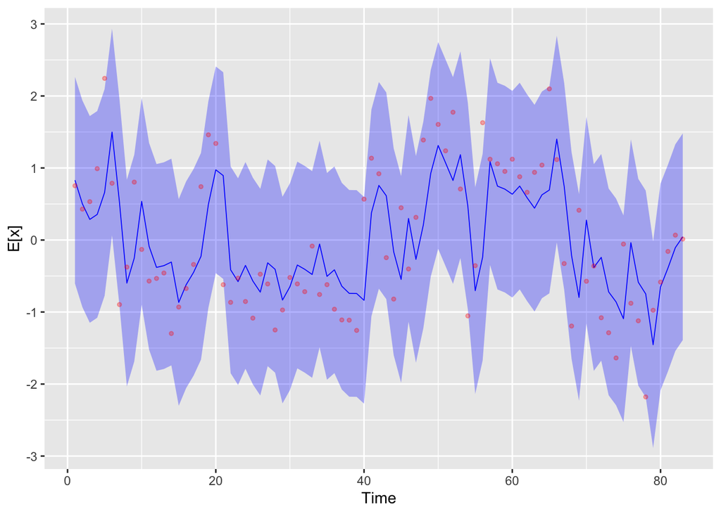

Maximum likelihood estimates of SDE fit to SST anomalies

```r
# setOU() taken from SDE package
setOU <- function(Dt, x0, theta){
  Ex <- theta[1]/theta[2]+(x0-theta[1]/theta[2])*exp(-theta[2]*Dt)
  Vx <- theta[3]^2*(1-exp(-2*theta[2]*Dt))/(2*theta[2])
  return(list(Ex=Ex,Vx=Vx))
}

states =  setOU(Dt = rep(1,nrow(d)-1), x0=x[1:(nrow(d)-1)], theta = c(0, ou.coe))
states = data.frame(Ex = states$Ex, Vx = states$Vx)
states$low = states$Ex - 1.96*sqrt(states$Vx)
states$hi = states$Ex + 1.96*sqrt(states$Vx)
states$obs = d$sst.anom[-1]
states$time = seq(1,nrow(d)-1)

ggplot(states, aes(time,Ex)) +
  geom_ribbon(aes(ymin=low,ymax=hi), alpha=0.3,fill="blue") +
  geom_line(col="blue",size=0.3) +
  xlab("Time") + ylab("E[x]") +
  geom_point(aes(time,obs),col="red",alpha=0.3,size=1)
```

Just to largely confirm that the Bayesian analytical version is equivalent, we can run the model in Stan,

```r
data_list = list(
  N = nrow(d),
  obs_y = c(d$sst.anom)
)

fit_1 = stan("code/ar1_analytical.stan",
  data = data_list,
  pars = c("sigma","pred_y","tau"),
  iter=5000,
  chains=1,
  control=list(adapt_delta=0.99, max_treedepth=20))
pars = rstan::extract(fit_1)
states$bayes_exact = apply(pars$pred_y,2,mean)[-1]
states$bayes_exact[1] = NA
```

And of course this gives perfectly correlated values,

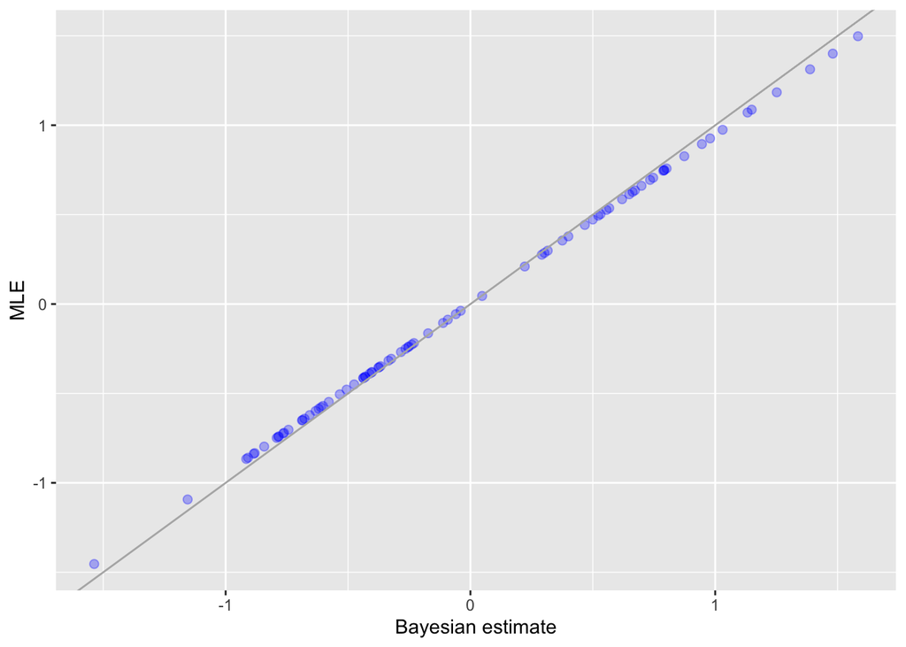

Bayesian analytical estimates vs MLE analytical estimates

As a second Bayesian model, we’ll move away from the analytical solution and try to use the Euler approximation. This is considerably slower (the step size here is $1/M$, where $M = 2$ for speed).

```r
data_list = list(
  N = nrow(d),
  M = 2, # resolution, should be higher than 10 (more like 100 or 1000)
  obs_y = c(d$sst.anom)
)

fit_2 = stan("code/ar1.stan",
  data = data_list,
  pars = c("sigma","pred_y","tau"),
  iter=5000,
  chains=1,
  control=list(adapt_delta=0.99, max_treedepth=20))
pars = rstan::extract(fit_2)
states$bayes_euler = apply(pars$pred_y,2,mean)[-1]
```

In some ways, this approach is too flexible – the euler approximation gives better estimates (closer to data) than the analytical solutions do.

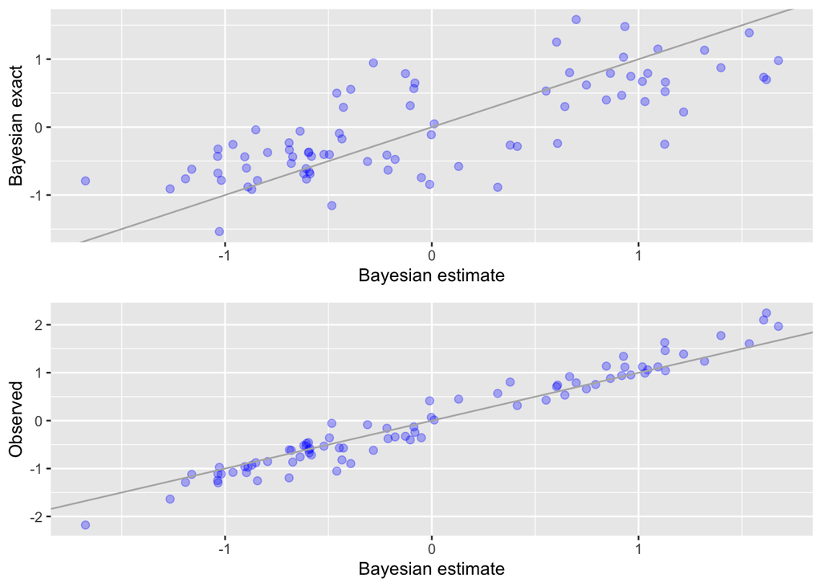

Bayesian analytical estimates vs Bayesian approximation

Finally, we can add the state-space component to the Euler implementation, where the data include a measurement / observation error.

```r
data_list = list(
  N = nrow(d),
  M = 2, # resolution, should be higher than 10 (more like 100 or 1000)
  obs_y = c(d$sst.anom)
)

fit_3 = stan("code/ar1_ss.stan",
  data = data_list,
  pars = c("sigma","pred_y","tau","obs_sigma"),
  iter=8000,
  chains=1,
  control=list(adapt_delta=0.99, max_treedepth=20))
pars = rstan::extract(fit_3)
states$bayes_euler_ss = apply(pars$pred_y,2,mean)[-1]
```

Again, these approaches yield similar results – and near perfect fits to the data.

[figure not shown]

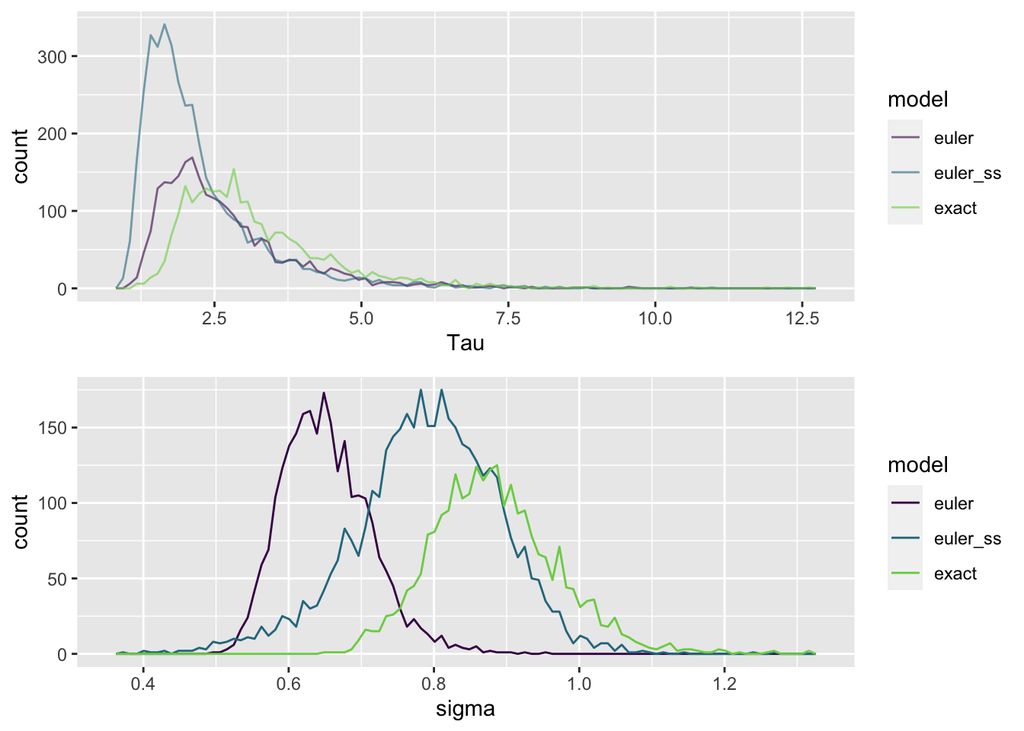

## Red noise time series

Red noise time series can be created from white noise time series by including the AR component. This example uses the same terminology in oceanography models (DiLorenzo et al.), where $f$ is a forcing variable (white noise), and $\gamma$ is the ‘1/(decorrelation timescale)’.

```r
ar_ls = function(time,forcing,gamma) {
  #S(t+1) = (1-GAMMA*DT)*S(t) + F(t)*DT
  forcing = c(forcing - mean(forcing))
  T=length(forcing)
  sig = 0

  for(t in 1:(T-1)) {
    #sig[t+1] = -theta*sig[t] + forcing[t]
    sig[t+1] = (1-gamma)*sig[t] + forcing[t]
  }

  # next estimates are linearly de-trended
  sig = sig - lm(sig ~ time)$fitted.values
  # interpolate output on the original time grid
  s.sig=(sig[-1]+sig[-T])/2 # midpoint
  # final step is normalize
  s.sig=s.sig/sd(s.sig)
  return(s.sig)
}
```

We can plot several red noise series with the same deviations, but different values of gamma,

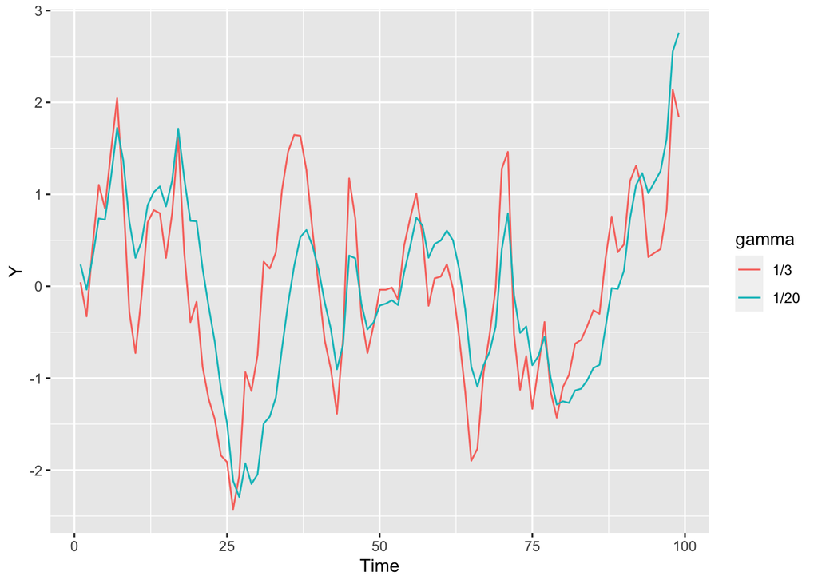

```r
set.seed(123)
x = rnorm(100)
df = rbind(data.frame("t"=1:99, "y"=ar_ls(1:100, x, 1/3),"gamma"="1/3"),
data.frame("t"=1:99, "y"=ar_ls(1:100, x, 1/20),"gamma"="1/20"))

ggplot(df, aes(t,y,group=gamma,col=gamma)) + geom_line() +
  xlab("Time") + ylab("Y")
```

## AR(1) SDE model (covariates)

In the above approaches, the white noise deviations were all estimated. In this extension, we’ll treat them all as known (referred to in oceanography literature as forcing variables, e.g. Cummings and Lagerloef 2002).

In this first example, we’ll use the same least squares approach that has been used previously (Chhak et al. 2009, Di Lorenzo et al. 2010). In addition to finding the solution with least squares, note that this approach isn’t estimating the process variance (because of the standardization). This function is the basic AR-1 model and can be embedded in optim() to to optimization. Using our original example,

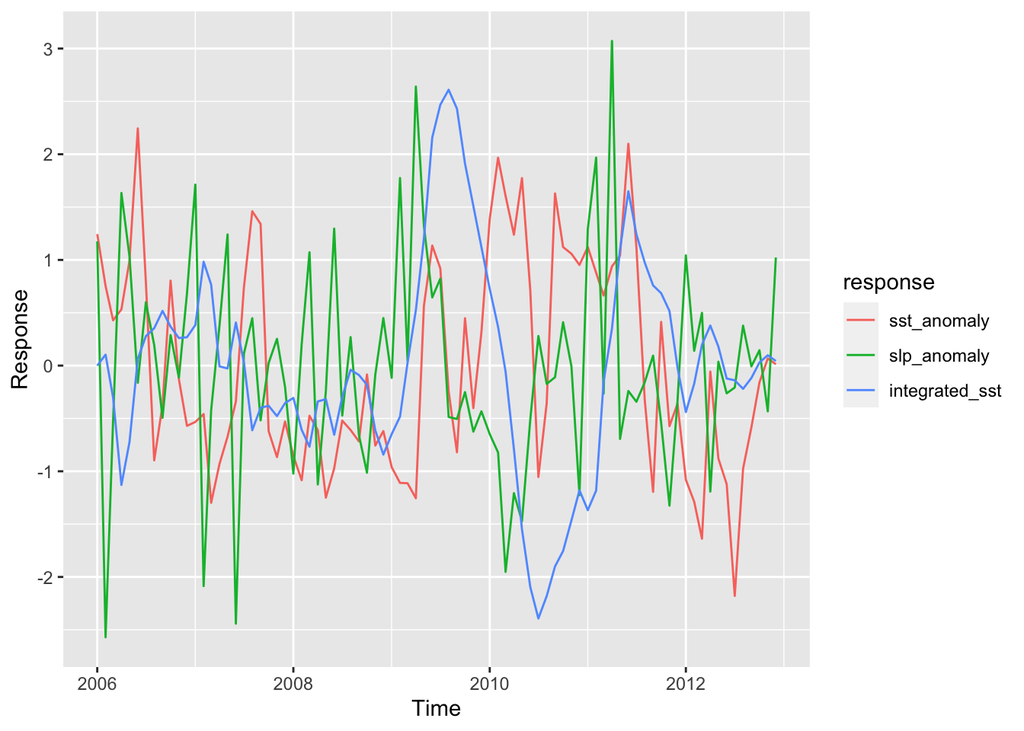

```r
d = read.csv("data/example slp sst data.csv",
  stringsAsFactors = FALSE)

# filter out NAs
d = dplyr::filter(d, !is.na(sst.anom), year>=2006)

d$date = lubridate::parse_date_time(x = paste(d$year,d$month,"01"),orders="ymd",tz="Pacific")
# scale
d$sst.anom = scale(d$sst.anom)
d$slp.anom.lag2 = scale(d$slp.anom.lag2)

calc_ss = function(theta) {
  pred_ts = ar_ls(1:nrow(d), forcing=d$slp.anom.lag2, theta)
  ss = -sum((pred_ts - d$sst.anom[-1])^2) # return -SS for optim
}

o = optimize(f=calc_ss, interval = c(0,1))

pred_ts = ar_ls(1:nrow(d), forcing=d$slp.anom.lag2, gamma = o$minimum)

df = rbind(data.frame("t"=d$date, "y"=d$sst.anom,"response"="sst_anomaly"),
  data.frame("t"=d$date, "y"=d$slp.anom.lag2,"response"="slp_anomaly"),
  data.frame("t"=d$date, "y"=c(0,as.numeric(pred_ts)),"response"="integrated_sst"))

ggplot(df, aes(t, y, group=response,col=response)) + geom_line() +
  xlab("Time") + ylab("Response")
```

### Bayesian implementation

We can’t do the exact Bayesian equivalent – because the approach above uses the sum of squares, rather than likelihood. But we can tweak the above approach to have an estimated observation error component.

```r
data_list = list(
  N = nrow(d),
  M = 1, # resolution, should be higher than 10 (more like 100 or 1000)
  obs_y = c(d$sst.anom),
  obs_x = c(d$slp.anom.lag2)
)

fit = stan("code/ar1_forcing_ss.stan",
  data = data_list,
  pars = c("sigma","pred_y","tau","obs_sigma"),
  iter=3000,
  chains=1,
  control=list(adapt_delta=0.99, max_treedepth=20))
```

[output not shown]

```r
pars = rstan::extract(fit)
```

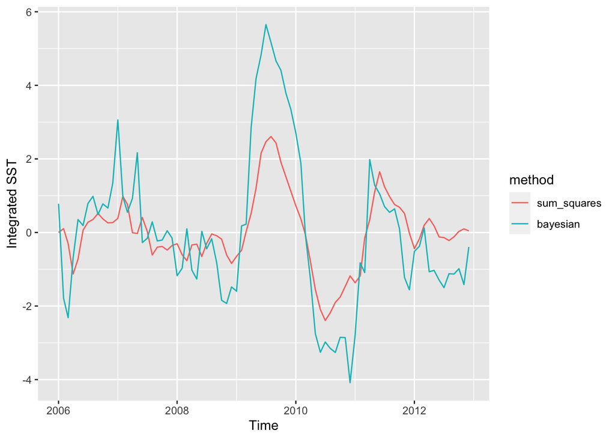

Bayesian vs SS estimates when forcing variable rather than white noise is included

```r
df = rbind(data.frame("t"=d$date, "y"=c(0,as.numeric(pred_ts)),"method"="sum_squares"),
  data.frame("t"=d$date, "y"=apply(pars$pred_y,2,mean),"method"="bayesian")
  )

ggplot(df, aes(t, y, group=method,col=method)) + geom_line() +
  xlab("Time") + ylab("Integrated SST")
```

Finally, we can put some credible intervals on our estimated integrated SST.

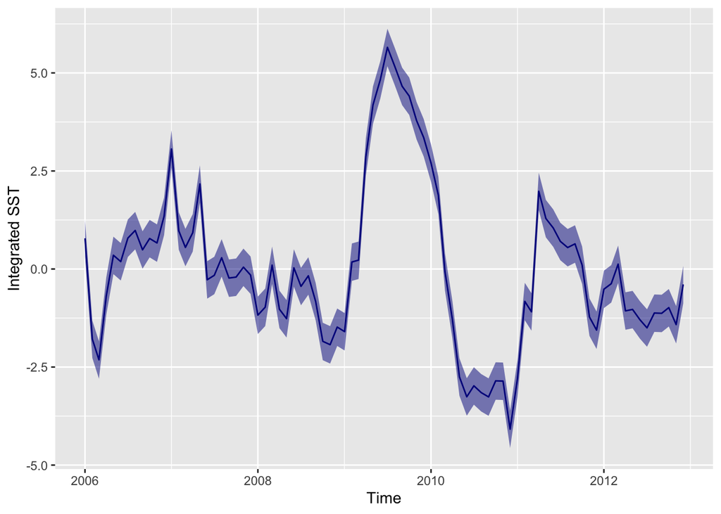

```r
df = data.frame("t"=d$date,
  "y"=apply(pars$pred_y,2,mean),
  "low"=apply(pars$pred_y,2,quantile,0.025),
  "hi"=apply(pars$pred_y,2,quantile,0.975))

ggplot(df, aes(t, y)) +
  geom_ribbon(aes(ymin = low, ymax = hi),fill="darkblue",alpha=0.5) +
  geom_line(col="darkblue") +
  xlab("Time") + ylab("Integrated SST")
```